# Project Week 4

# Pemodelan DLM & ARDL

```r
#sama dengan model dlm q=1
cons_lm1 <- dynlm(Yt ~ Xt+L(Xt),data = latih.ts)
#sama dengan model ardl p=1 q=0
cons_lm2 <- dynlm(Yt ~ Xt+L(Yt),data = latih.ts)
#sama dengan ardl p=1 q=1
cons_lm3 <- dynlm(Yt ~ Xt+L(Xt)+L(Yt),data = latih.ts)
#sama dengan dlm p=2
cons_lm4 <- dynlm(Yt ~ Xt+L(Xt)+L(Xt,2),data = latih.ts)
```

## Ringkasan Model

```r
summary(cons_lm1)
```

```
##
## Time series regression with "ts" data:
## Start = 2, End = 75
##
## Call:
## dynlm(formula = Yt ~ Xt + L(Xt), data = latih.ts)
##
## Residuals:
##     Min      1Q  Median      3Q     Max
## -0.4475 -0.3303 -0.1805  0.3030  0.9804
##
## Coefficients:
##              Estimate Std. Error t value Pr(>|t|)
## (Intercept)  2.812336   0.233345  12.052   <2e-16 ***
## Xt           0.008102   0.008275   0.979    0.331
## L(Xt)       -0.005695   0.008219  -0.693    0.491
## ---
## Signif. codes:  0 '***' 0.001 '**' 0.01 '*' 0.05 '.' 0.1 ' ' 1
##
## Residual standard error: 0.4271 on 71 degrees of freedom
## Multiple R-squared:  0.01671,    Adjusted R-squared:  -0.01099
## F-statistic: 0.6032 on 2 and 71 DF,  p-value: 0.5498
```

```r
summary(cons_lm2)
```

```
##
## Time series regression with "ts" data:
## Start = 2, End = 75
##
## Call:
## dynlm(formula = Yt ~ Xt + L(Yt), data = latih.ts)
##
## Residuals:
##       Min        1Q    Median        3Q       Max
## -0.120521 -0.030866 -0.006299  0.024294  0.200504
##
## Coefficients:
##               Estimate Std. Error t value Pr(>|t|)
## (Intercept)  0.0973037  0.0490759   1.983  0.05127 .
## Xt          -0.0013678  0.0004225  -3.238  0.00183 **
## L(Yt)        1.0021811  0.0148630  67.428  < 2e-16 ***
## ---
## Signif. codes:  0 '***' 0.001 '**' 0.01 '*' 0.05 '.' 0.1 ' ' 1
##
## Residual standard error: 0.05314 on 71 degrees of freedom
## Multiple R-squared:  0.9848, Adjusted R-squared:  0.9843
## F-statistic:  2297 on 2 and 71 DF,  p-value: < 2.2e-16
```

```r
summary(cons_lm3)
```

```
##
## Time series regression with "ts" data:
## Start = 2, End = 75
##
## Call:
## dynlm(formula = Yt ~ Xt + L(Xt) + L(Yt), data = latih.ts)
##
## Residuals:
##       Min        1Q    Median        3Q       Max
## -0.116895 -0.030782 -0.005703  0.022862  0.198807
##
## Coefficients:
##               Estimate Std. Error t value Pr(>|t|)
## (Intercept)  0.0933023  0.0500760   1.863   0.0666 .
## Xt          -0.0018171  0.0010459  -1.737   0.0867 .
## L(Xt)        0.0004854  0.0010325   0.470   0.6397
## L(Yt)        1.0028131  0.0150055  66.830   <2e-16 ***
## ---
## Signif. codes:  0 '***' 0.001 '**' 0.01 '*' 0.05 '.' 0.1 ' ' 1
##
## Residual standard error: 0.05343 on 70 degrees of freedom
## Multiple R-squared:  0.9848, Adjusted R-squared:  0.9842
## F-statistic:  1514 on 3 and 70 DF,  p-value: < 2.2e-16
```

```r
summary(cons_lm4)
```

```
##
## Time series regression with "ts" data:
## Start = 3, End = 75
##
## Call:
## dynlm(formula = Yt ~ Xt + L(Xt) + L(Xt, 2), data = latih.ts)
##
## Residuals:
##     Min      1Q  Median      3Q     Max
## -0.4471 -0.3196 -0.1882  0.3057  1.0007
##
## Coefficients:
##               Estimate Std. Error t value Pr(>|t|)
## (Intercept)  2.8846828  0.2423526  11.903   <2e-16 ***
## Xt           0.0088994  0.0085560   1.040    0.302
## L(Xt)        0.0004785  0.0102957   0.046    0.963
## L(Xt, 2)    -0.0080669  0.0084303  -0.957    0.342
## ---
## Signif. codes:  0 '***' 0.001 '**' 0.01 '*' 0.05 '.' 0.1 ' ' 1
##
## Residual standard error: 0.4284 on 69 degrees of freedom
## Multiple R-squared:  0.02481,    Adjusted R-squared:  -0.01759
## F-statistic: 0.585 on 3 and 69 DF,  p-value: 0.6268
```

## Akurasi SSE

```r
deviance(cons_lm1)
```

```
## [1] 12.94937
```

```r
deviance(cons_lm2)
```

```
## [1] 0.2004589
```

```r
deviance(cons_lm3)
```

```
## [1] 0.1998279
```

```r
deviance(cons_lm4)
```

```
## [1] 12.66104
```

## Uji diagnostik

```r
if(require("lmtest")) encomptest(cons_lm1, cons_lm2)
```

```
## Encompassing test
##
## Model 1: Yt ~ Xt + L(Xt)
## Model 2: Yt ~ Xt + L(Yt)
## Model E: Yt ~ Xt + L(Xt) + L(Yt)
##           Res.Df Df        F Pr(>F)
## M1 vs. ME     70 -1 4466.183 <2e-16 ***
## M2 vs. ME     70 -1    0.221 0.6397
## ---
## Signif. codes:  0 '***' 0.001 '**' 0.01 '*' 0.05 '.' 0.1 ' ' 1
```

### Pengecekan autokorelasi

```r
dwtest(cons_lm1)
```

```
##
##  Durbin-Watson test
##
## data:  cons_lm1
## DW = 0.047457, p-value < 2.2e-16
## alternative hypothesis: true autocorrelation is greater than 0
```

```r
dwtest(cons_lm2)
```

```
##
##  Durbin-Watson test
##
## data:  cons_lm2
## DW = 1.1837, p-value = 4.217e-05
## alternative hypothesis: true autocorrelation is greater than 0
```

```r
dwtest(cons_lm3)
```

```
##
##  Durbin-Watson test
##
## data:  cons_lm3
## DW = 1.1771, p-value = 4.116e-05
## alternative hypothesis: true autocorrelation is greater than 0
```

```r
dwtest(cons_lm4)
```

```
##
##  Durbin-Watson test
##
## data:  cons_lm4
## DW = 0.062521, p-value < 2.2e-16
## alternative hypothesis: true autocorrelation is greater than 0
```

### Heterogenitas

```r
bptest(cons_lm1)
```

```
##
##  studentized Breusch-Pagan test
##
## data:  cons_lm1
## BP = 7.0686, df = 2, p-value = 0.02918
```

```r
bptest(cons_lm2)
```

```
##
##  studentized Breusch-Pagan test
##
## data:  cons_lm2
## BP = 4.3184, df = 2, p-value = 0.1154
```

```r
bptest(cons_lm3)
```

```
##
##  studentized Breusch-Pagan test
##
## data:  cons_lm3
## BP = 4.8725, df = 3, p-value = 0.1814
```

```r
bptest(cons_lm4)
```

```
##
##  studentized Breusch-Pagan test
##
## data:  cons_lm4
## BP = 5.8088, df = 3, p-value = 0.1213
```

### Normalitas

```r
shapiro.test(residuals(cons_lm1))
```

```
##
##  Shapiro-Wilk normality test
##
## data:  residuals(cons_lm1)
## W = 0.84115, p-value = 1.962e-07
```

```r
shapiro.test(residuals(cons_lm2))
```

```
##
##  Shapiro-Wilk normality test
##
## data:  residuals(cons_lm2)
## W = 0.94185, p-value = 0.001986
```

```r
shapiro.test(residuals(cons_lm3))
```

```
##
##  Shapiro-Wilk normality test
##
## data:  residuals(cons_lm3)
## W = 0.94561, p-value = 0.003122
```

```r
shapiro.test(residuals(cons_lm4))
```

```
##
##  Shapiro-Wilk normality test
##
## data:  residuals(cons_lm4)
## W = 0.83407, p-value = 1.376e-07
```

# Perbandingan model

```r
akurasi <- matrix(c(mape.koyck, mape.dlm, mape.dlm2, mape.ardl))
row.names(akurasi)<- c("Koyck","DLM 1","DLM 2","Autoregressive")
colnames(akurasi) <- c("MAPE")
akurasi
```

```
##                      MAPE
## Koyck          0.06303338
## DLM 1          0.13750475
## DLM 2          0.14309491
## Autoregressive 0.06635979
```

Berdasarkan nilai MAPE, model Koyck dianggap paling baik karena memiliki nilai MAPE yang paling kecil.

# Plot

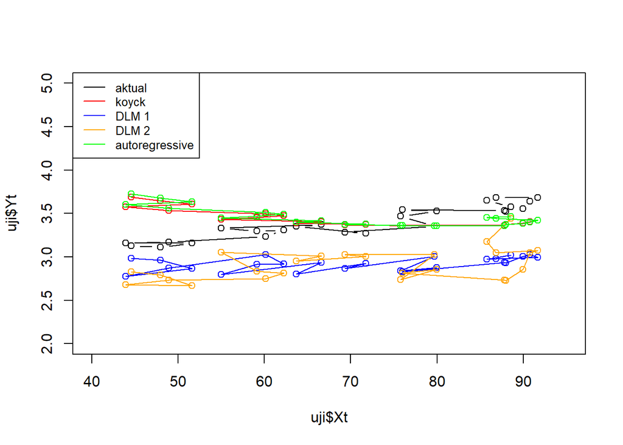

```r
par(mfrow=c(1,1))
plot(uji$Xt, uji$Yt, type="b", col="black", xlim=c(40,95), ylim=c(2,5))
points(uji$Xt, fore.koyck$forecasts,col="red")
lines(uji$Xt, fore.koyck$forecasts,col="red")
points(uji$Xt, fore.dlm$forecasts,col="blue")
lines(uji$Xt, fore.dlm$forecasts,col="blue")
points(uji$Xt, fore.dlm2$forecasts,col="orange")
lines(uji$Xt, fore.dlm2$forecasts,col="orange")
points(uji$Xt, fore.ardl$forecasts,col="green")
lines(uji$Xt, fore.ardl$forecasts,col="green")
legend("topleft",c("aktual", "koyck","DLM 1","DLM 2", "autoregressive"), lty=1, col=c("black","red","blue","orange","green"), cex=0.8)
```

Berdasarkan *plot* di atas, terlihat bahwa *plot* model Koyck paling mendekati data aktual. Maka dari itu, dapat disimpulkan bahwa model yang terbaik adalah model regresi Koyck.

## Plot data aktual dengan Koyck

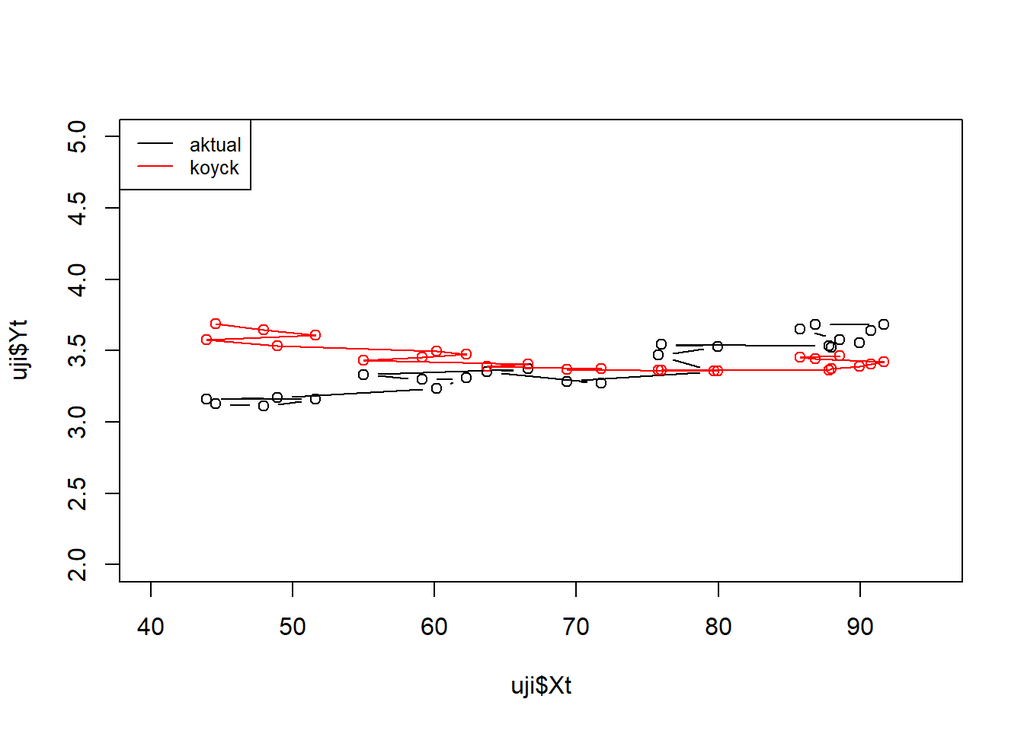

```r
par(mfrow=c(1,1))
plot(uji$Xt, uji$Yt, type="b", col="black", xlim=c(40,95), ylim=c(2,5))
points(uji$Xt, fore.koyck$forecasts,col="red")
lines(uji$Xt, fore.koyck$forecasts,col="red")
legend("topleft",c("aktual", "koyck"), lty=1, col=c("black","red"), cex=0.8)
```

# Uji asumsi model Koyck

## Autokorelasi

```r
dwtest(model.koyck$model)
```

```
##
##  Durbin-Watson test
##
## data:  model.koyck$model
## DW = 1.1837, p-value = 4.217e-05
## alternative hypothesis: true autocorrelation is greater than 0
```

## Heterogenitas

```r
bptest(model.koyck$model)
```

```
##
##  studentized Breusch-Pagan test
##
## data:  model.koyck$model
## BP = 4.3184, df = 2, p-value = 0.1154
```

## Normalitas

```r
shapiro.test(residuals(model.koyck$model))
```

```
##
##  Shapiro-Wilk normality test
##
## data:  residuals(model.koyck$model)
## W = 0.9401, p-value = 0.001614
```

Berdasarkan uji asumsi yang dilakukan, kesimpulan yang dapat diambil adalah : 1. Model Koyck terindikasi memiliki autokorelasi 2. Ragam sisaan model Koyck homogen 3. Sisaan model Koyck tidak menyebar normal